# Multilevel leaf decomposition model example

Bob Hall

8 March 2023

## The problem

We want to measure leaf decomposition in 6 streams that vary in temperature to measure leaf litter decomposition. This example is not as contrived as it seems, some streams in Iceland vary from 5 degC to 25 degC within a kilometer of each other.

## Synthesize data.

For a multilevel model, start at he top level and sythesize downward. In this case, we start with a temperature vs $k$ model for streams $j$.
$$log(k_j)\sim normal( log (c) +
(-0.65(\frac{1}{(K_B\times T_j)} - \frac{1}{(K_B\times 283.15)} ) ),
\sigma_j)$$
$T$ is absolute temperature (K), $c$ is a constant (set to 0.01), $K_B$ is the Boltzmann constant. This function is called an Arrhenius function and should be familiar from courses in physiology. In case the above equation is too much, we can more simply write (ignoring the probability)
$$k=c\times e^{\frac{-0.65}{K_B T}}$$
.
See Brown et al. 2004 Ecology for more information on this equation. The value 0.65 (units are eV) represents the activation energy for cellular respiration. It is roughly equal to a Q$_{10}$ = 2 (which is something else I hope you remember from physiology)

Now, make a vector of $k_j$ with some random normal error.

```r
temp<- c(5,8,13,15,20,22)+273.15

KB<-8.61e-5
log.k.true<-   log (0.01* exp(-0.65* (1/(KB*temp) - 1/(KB*283.15)   ) ))

log.k.true.err<-log.k.true+rnorm(6, 0,0.25)
exp(log.k.true.err)
```

```
## [1] 0.005922677 0.007385107 0.016059633 0.016999118 0.024998520 0.047316865
```

```r
time<- c( 5, 10, 20, 30, 45, 60, 75, 90, 120)
```

Now use these values of randomly chosen $k_j$ to derive leaf mass data based on the well-known exponential decay model $M_{t,j}=e^{-K_jt}$, and then make a dataframe.

```r
samp_n<-length(time)

stream<-rep(1:6, each=samp_n)
kstream<-rep(log.k.true.err, each=samp_n)+ rnorm(60,0,0.1) #adding error in log, so multiplicative
mass<-exp(- (exp(kstream)*time))  #Since kstream is logged we need to exponentiate first

Kdf<- data.frame(stream=stream, kstream=kstream ,mass=mass, time= rep(time,6) )
```

### A better way to fake the data: using the beta distribution

Here instead of generating random normal $K$ we instead use the bata distribution. We can reparameterize the beta distribution such that $\alpha = \mu \times \phi$ and $\beta = (1-\mu) \times \phi$. $\phi$ in this case relates to the variance. Play with it, I adjusted to get some amount of error in the data.

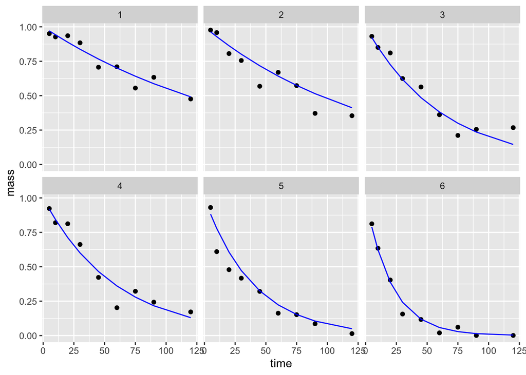

```r
time<- c( 5, 10, 20, 30, 45, 60, 75, 90, 120)
samp_n<-length(time)
stream<-rep(1:6, each=samp_n)
kstream.true<-rep(log.k.true.err, each=samp_n)
mass.true<-exp(- (exp(kstream.true)*time)) #exponetial decay
phi=60
alpha<-mass.true*phi
beta<-  (1-mass.true)*phi
mass<- rbeta(length(kstream.true), alpha, beta )
Kdf<- data.frame(stream=stream, kstream=kstream.true ,mass=mass, time= rep(time,6) )

ggplot(Kdf, aes(time, mass)) +
  geom_point() +
   geom_line(data = Kdf, aes(x = time, y = mass.true), color="blue")+
  facet_wrap(. ~ stream)
```

There are the data. Blue line is the true data

## The Stan model

The model we use is:

```r
sink("mult_decomp_beta.stan")

cat("

    data {
    int<lower = 1> N;
    int<lower = 1> nstreams;
    int<lower = 1> streamID[N];
    vector[N] time;
    vector[N] mass;
    vector[nstreams] temp;
    real KB;
    }

    parameters {
    vector <upper = 0> [nstreams] logk;
    //real <lower = 0> intercept;
    real<lower = 0.1> phi; //
    real slope_k_T;
    real int_k_T;
    real <lower = 0> sigma_stream;


    }

    transformed parameters{

    vector <lower=0.00001> [nstreams] k;
     vector <lower=0, upper=1>[N] yhat;
      vector <lower=0 > [N] alpha;
     vector <lower=0 > [N] B;


k=exp(logk);

for (i in 1:N){
      yhat[i]= 1 * exp(-k[streamID[i]]*time[i]);
       alpha[i] = yhat[i]*phi;
      B[i] = (1-yhat[i])*phi;
}



    }
    model {
    for (i in 1:N){
    mass[i] ~ beta(alpha[i],B[i]); // likelihood
    }
    for (j in 1:nstreams){
    logk[j]~normal( log(int_k_T) + slope_k_T * (1/(KB*temp[j]) - 1/(KB*283.15)   ) , sigma_stream);
    }

    int_k_T ~normal(0,0.1);
    slope_k_T~normal(0,1);
    sigma_stream~normal (0,2);

    }

    "
    ,fill=TRUE)
sink()
```

Make a list (I did this for you) and run the model

```r
decomp.dat<- list( N= length(Kdf$stream), nstreams=6, streamID=Kdf$stream, time=Kdf$time, mass=Kdf$mass, temp=temp, KB=8.61e-5)

fit <- stan("/Users/bob.hall/ecomodels/mult_decomp_beta.stan", data = decomp.dat,  iter = 1000, chains = 4)
```

```
## Trying to compile a simple C file
```

[output not shown]

Look at output of the model:

```r
print(fit)
```

```
## Inference for Stan model: mult_decomp_beta.
## 4 chains, each with iter=1000; warmup=500; thin=1;
## post-warmup draws per chain=500, total post-warmup draws=2000.
##
##                mean se_mean   sd  2.5%    25%    50%    75%  97.5% n_eff Rhat
## logk[1]       -5.10    0.00 0.09 -5.28  -5.17  -5.10  -5.04  -4.93  1426 1.00
## logk[2]       -4.73    0.00 0.08 -4.88  -4.79  -4.73  -4.68  -4.58  1292 1.00
## logk[3]       -4.21    0.00 0.07 -4.34  -4.25  -4.21  -4.16  -4.07  1667 1.00
## logk[4]       -4.06    0.00 0.07 -4.20  -4.11  -4.07  -4.02  -3.93  1290 1.00
## logk[5]       -3.52    0.00 0.07 -3.66  -3.56  -3.52  -3.47  -3.39  1670 1.00
## logk[6]       -3.04    0.00 0.07 -3.18  -3.09  -3.04  -3.00  -2.91  1141 1.00
## phi           47.80    0.25 9.62 30.78  40.80  46.99  53.96  68.28  1473 1.00
## slope_k_T     -0.79    0.00 0.12 -1.00  -0.86  -0.79  -0.73  -0.54   927 1.00
## int_k_T        0.01    0.00 0.00  0.01   0.01   0.01   0.01   0.01  1070 1.00
## sigma_stream   0.20    0.01 0.14  0.07   0.12   0.16   0.24   0.55   580 1.00
## k[1]           0.01    0.00 0.00  0.01   0.01   0.01   0.01   0.01  1463 1.00
## k[2]           0.01    0.00 0.00  0.01   0.01   0.01   0.01   0.01  1297 1.00
## k[3]           0.01    0.00 0.00  0.01   0.01   0.01   0.02   0.02  1691 1.00
## k[4]           0.02    0.00 0.00  0.01   0.02   0.02   0.02   0.02  1237 1.00
## k[5]           0.03    0.00 0.00  0.03   0.03   0.03   0.03   0.03  1658 1.00
## k[6]           0.05    0.00 0.00  0.04   0.05   0.05   0.05   0.05  1154 1.00
## yhat[1]        0.97    0.00 0.00  0.96   0.97   0.97   0.97   0.97  1462 1.00
## yhat[2]        0.94    0.00 0.01  0.93   0.94   0.94   0.94   0.95  1461 1.00
## yhat[3]        0.89    0.00 0.01  0.86   0.88   0.89   0.89   0.90  1459 1.00
## yhat[4]        0.83    0.00 0.01  0.80   0.82   0.83   0.84   0.86  1457 1.00
## yhat[5]        0.76    0.00 0.02  0.72   0.75   0.76   0.77   0.80  1453 1.00
## yhat[6]        0.69    0.00 0.02  0.65   0.68   0.69   0.71   0.74  1450 1.00
## yhat[7]        0.63    0.00 0.03  0.58   0.62   0.63   0.65   0.68  1447 1.00
## yhat[8]        0.58    0.00 0.03  0.52   0.56   0.58   0.60   0.63  1444 1.00
## yhat[9]        0.48    0.00 0.03  0.42   0.46   0.48   0.50   0.54  1437 1.00
## yhat[10]       0.96    0.00 0.00  0.95   0.95   0.96   0.96   0.96  1297 1.00
## yhat[11]       0.92    0.00 0.01  0.90   0.91   0.92   0.92   0.93  1297 1.00
## yhat[12]       0.84    0.00 0.01  0.82   0.83   0.84   0.85   0.86  1297 1.00
## yhat[13]       0.77    0.00 0.02  0.74   0.76   0.77   0.78   0.80  1296 1.00
## yhat[14]       0.67    0.00 0.02  0.63   0.66   0.67   0.69   0.71  1296 1.00
## yhat[15]       0.59    0.00 0.02  0.54   0.57   0.59   0.61   0.63  1295 1.00
## yhat[16]       0.52    0.00 0.03  0.46   0.50   0.52   0.53   0.57  1294 1.00
## yhat[17]       0.45    0.00 0.03  0.40   0.43   0.45   0.47   0.50  1293 1.00
## yhat[18]       0.35    0.00 0.03  0.29   0.33   0.35   0.37   0.40  1292 1.00
## yhat[19]       0.93    0.00 0.00  0.92   0.93   0.93   0.93   0.94  1690 1.00
```

[output cut: 134 more lines]

```
## B[46]         10.19    0.06 2.30  6.22   8.50  10.04  11.64  15.21  1370 1.00
## B[47]         18.20    0.11 4.04 11.19  15.24  17.92  20.75  27.01  1380 1.00
## B[48]         29.45    0.17 6.37 18.39  24.82  29.01  33.41  43.20  1397 1.00
## B[49]         36.41    0.21 7.72 22.91  30.87  35.87  41.22  53.26  1413 1.00
## B[50]         42.22    0.23 8.77 27.12  35.86  41.57  47.86  61.39  1433 1.00
## B[51]         45.06    0.24 9.24 28.82  38.36  44.37  50.95  64.97  1448 1.00
## B[52]         46.45    0.25 9.45 29.67  39.55  45.70  52.47  66.62  1457 1.00
## B[53]         47.13    0.25 9.55 30.18  40.17  46.32  53.14  67.46  1464 1.00
## B[54]         47.64    0.25 9.61 30.57  40.63  46.82  53.75  68.09  1470 1.00
## lp__         104.57    0.12 2.81 97.73 102.99 104.92 106.67 108.86   581 1.01
##
## Samples were drawn using NUTS(diag_e) at Wed Mar  8 21:40:29 2023.
## For each parameter, n_eff is a crude measure of effective sample size,
## and Rhat is the potential scale reduction factor on split chains (at
## convergence, Rhat=1).
```

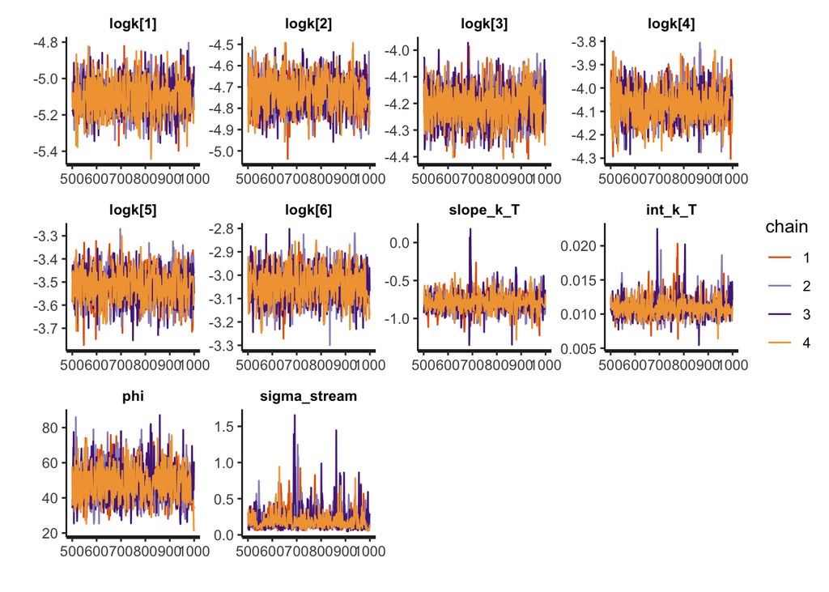

```r
traceplot(fit, pars =c("logk", "slope_k_T", "int_k_T", "phi", "sigma_stream"))
```

### Temp vs k plot

Now plot temp vs k and then and the error on the regression fit. I hope you have a strong stomach.

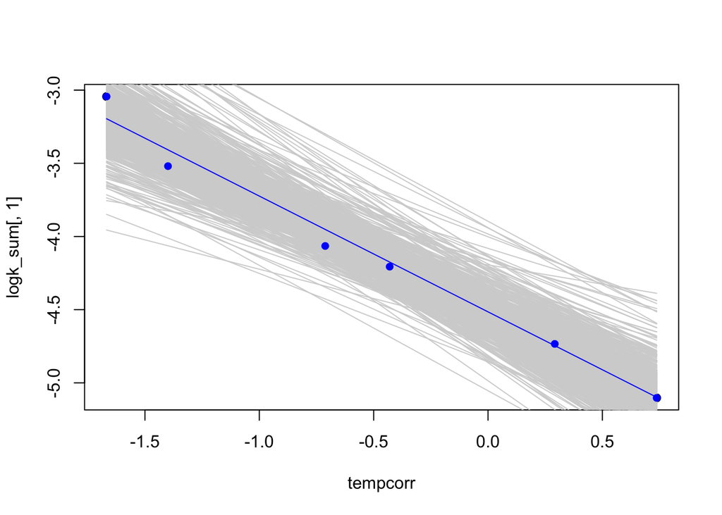

```r
tempcorr<-(1/(KB*temp) - 1/(KB*283.15)   )
logk_sum<- summary(fit, pars="logk")$summary
slope_int_sum<- summary(fit, pars=c("slope_k_T", "int_k_T "))$summary

samples_fit<- rstan::extract(fit, pars=c("slope_k_T ", "int_k_T" ))

plot (tempcorr, logk_sum[,1] )
for (i in 1:1000){
  lines(tempcorr, log(samples_fit$int_k_T[i]) + samples_fit$slope_k_T[i]*tempcorr, col='light gray')
}
points (tempcorr, logk_sum[,1], col='blue', pch=16)
lines(tempcorr, log(slope_int_sum[2,1]) +slope_int_sum[1,1]*tempcorr, col="blue" )
```

### A few things to take away

1. There is low error within streams, thus the estimates of $k_j$ are robust to the prior. That is, the likelihood wins.
2. But what about the value that we really care about, the slope of the k vs T? In the hierarchical model the slope mean = -0.7911429 and CI are (-1.0027948, -0.5406841). That is a lot of variation and is because of the within stream variation in proportion mass remaining. Even though it is low, it matters in the overall parameter estimates. I spent some time looking and could find no study that estimated leaf brerakdown this way in streams. Nearly all calculate the decay coefficient, $K$ and then proceed to do statistics on that values as if it were a data point. This procedure is conceptually incorrect.